# homework_smirnov_ve_stats3

## Задание:

Необходимо выбрать вероятностное распределение на ваш выбор, кроме самых простых (нормальное, равномерное, биномиальное), и в Jupyter Notebook (можно Google Colab) **провести следующие эксперименты:**

1. Для выбранного распределения сгенерируйте выборки разного объема и проиллюстрируйте сходимость выборочного среднего к математическому ожиданию (покажите наглядно стабилизацию выборочного среднего).
2. Наглядно продемонстрируйте центральную предельную теорему в действии для выбранного вами распределения (покажите сходимость с ростом выборки к нормальному распределению).
3. Сгенерируйте выборки маленького/среднего/большого размера и для каждой из них постройте:
   - асимптотический доверительный интервал для среднего значения на базе ЦПТ,
   - точный доверительный интервал для среднего значения (на базе t-критического значения),
   - эфронов доверительный интервал для среднего, медианы, моды, дисперсии.

Представьте по пунктам 3-5 сводный датафрейм в читабельном формате и предоставьте вывод о ширинах ДИ, есть ли соответствие фактическому распределению, откуда взята выборка.

```python
import numpy as np
import scipy.stats as sts
from scipy import stats
from statistics import variance

import matplotlib.pyplot as plt
import seaborn as sns
plt.style.use('ggplot')  # стиль для графиков
%matplotlib inline
```

### Задание 1. Для выбранного распределения сгенерируйте выборки разного объема и проиллюстрируйте сходимость выборочного среднего к математическому ожиданию (покажите наглядно стабилизацию выборочного среднего).

Выбираю **экспоненциальное распределение.**

Случайная величина X имеет экспоненциальное распределение с параметром λ > 0, если её плотность вероятности имеет вид:

$$ f_X(x) = \begin{cases} \lambda e^{-\lambda x}, & x \geq 0, \\ 0, & x < 0. \end{cases} $$

Математическое ожидание рассчитывается следующим образом: $$ \mathbb{E}[X] = \frac{1}{\lambda} $$

```
4.89
```

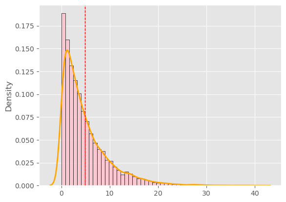

```python
np.random.seed(42)
lambda_e = 0.2
size = 10000
# Математическое ожидание для распределения с моими параметрами:
expected_exp_mean = 1 / lambda_e # scale

# Сделаем плотность
exp_distribution = np.random.exponential(scale=expected_exp_mean, size=size)
# Визуализируем
sns.histplot(exp_distribution, bins=50, kde=True, color="pink", edgecolor="black", alpha=0.8, stat="density")
sns.kdeplot(exp_distribution, color="orange", linewidth=2)
# Добавим среднее
mean_exp_distribution = round(exp_distribution.mean(),2)
plt.axvline(mean_exp_distribution, color='red', linewidth=1, linestyle='--', label='Avg_exp_dist')
mean_exp_distribution
```

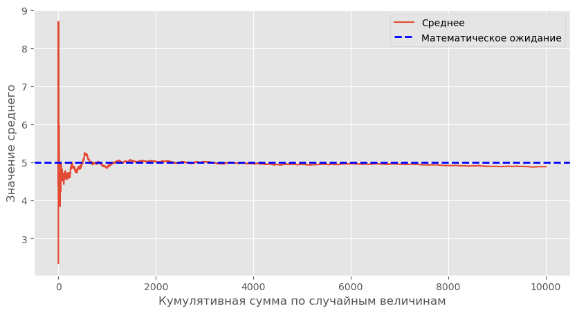

```python
# np.random.seed(42)
# lambda_e = 0.2
# scale_e = 1 / lambda_e
# size = 10**6
# # Математическое ожидание для распределения с моими параметрами:
# expected_exp_mean = 1 / lambda_e # scale
# # Сделаем плотность
# exp_distribution = np.random.exponential(scale=expected_exp_mean, size=size)

# Считаем кумулятивную сумму
exp_distribution_cumsum = np.cumsum(exp_distribution)
# Делим на число наблюдений
exp_distribution_cumsum_mean = exp_distribution_cumsum / np.arange(1, size + 1)

plt.figure(figsize=(10,5))
plt.plot(exp_distribution_cumsum_mean)
plt.axhline(expected_exp_mean, color='b', linestyle='dashed', linewidth=2)
plt.xlabel('Кумулятивная сумма по случайным величинам')
plt.ylabel('Значение среднего')
plt.legend(['Среднее', 'Математическое ожидание'])
```

#### А как еще можно посмотреть?

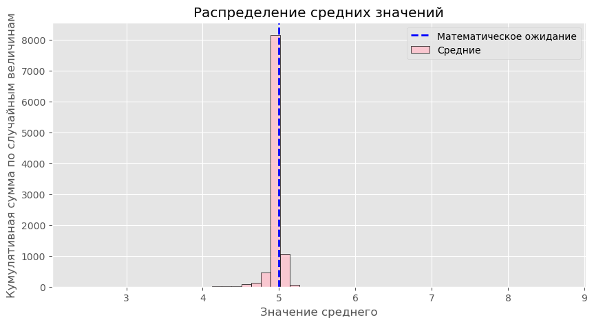

```python
plt.figure(figsize=(10,5))
sns.histplot(exp_distribution_cumsum_mean, kde=False, bins=50, color="pink", edgecolor="black", alpha=0.8)
plt.axvline(expected_exp_mean, color='b', linestyle='dashed', linewidth=2)
plt.xlabel('Значение среднего')
plt.ylabel('Кумулятивная сумма по случайным величинам')
plt.legend(['Математическое ожидание', 'Средние'])
plt.title('Распределение средних значений')
```

#### Вывод:

Среднее значение наблюдаемого распределения довольно-таки близко к математическому ожиданию экспоненциального распределения (4.89, 5.0). Среднее наблюдаемых значений приближается к математическому ожиданию случайной величины.

### Задание 2. Наглядно продемонстрируйте центральную предельную теорему в действии для выбранного вами распределения (покажите сходимость с ростом выборки к нормальному распределению).

#### **Была очень странная идея, которая, скорее всего, не является верной; оставлю ее в файле, а под ней приведу корректное решение**

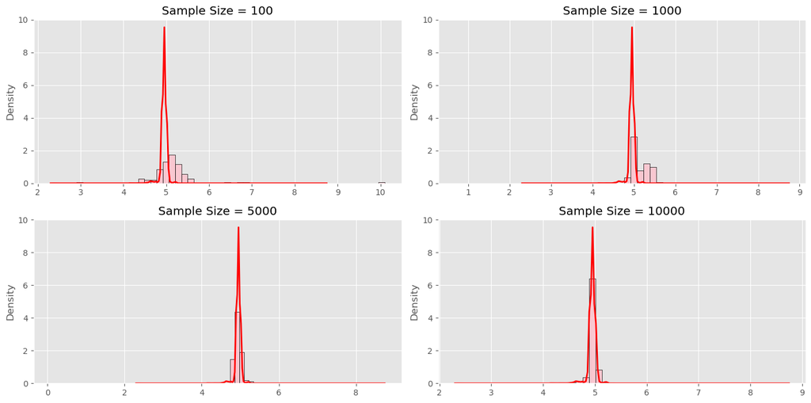

```python
np.random.seed(42)
lambda_e = 0.2
size = 10000
# Математическое ожидание для распределения
expected_exp_mean = 1 / lambda_e  # scale

# Генерация распределения
exp_distribution = np.random.exponential(scale=expected_exp_mean, size=size)

# Считаем кумулятивную сумму для исходного набора данных
exp_distribution_cumsum = np.cumsum(exp_distribution)
# Делим на число наблюдений для исходного набора данных
exp_distribution_cumsum_mean = exp_distribution_cumsum / np.arange(1, size + 1)

# Размеры выборок
size1 = 100
size2 = 1000
size3 = 5000

sample1 = np.random.choice(exp_distribution, size=size1, replace=True)
sample2 = np.random.choice(exp_distribution, size=size2, replace=True)
sample3 = np.random.choice(exp_distribution, size=size3, replace=True)

# Считаем кумулятивную сумму
sample1_cumsum = np.cumsum(sample1)
# Делим на число наблюдений
sample1_cumsum_mean = sample1_cumsum / np.arange(1, size1 + 1)

# Считаем кумулятивную сумму
sample2_cumsum = np.cumsum(sample2)
# Делим на число наблюдений
sample2_cumsum_mean = sample2_cumsum / np.arange(1, size2 + 1)


# Считаем кумулятивную сумму
sample3_cumsum = np.cumsum(sample3)
# Делим на число наблюдений
sample3_cumsum_mean = sample3_cumsum / np.arange(1, size3 + 1)

# Создаём подграфики
fig, axes = plt.subplots(2, 2, figsize=(14, 7))

# Визуализируем

# 1
sns.histplot(sample1_cumsum_mean, bins=50, kde=False, color="pink", edgecolor="black", alpha=0.8, stat="density", ax=axes[0, 0])
sns.kdeplot(exp_distribution_cumsum_mean, color="red", linewidth=2, ax=axes[0, 0])
axes[0, 0].set_title("Sample Size = 100")

# 2
sns.histplot(sample2_cumsum_mean, bins=50, kde=False, color="pink", edgecolor="black", alpha=0.8, stat="density", ax=axes[0, 1])
sns.kdeplot(exp_distribution_cumsum_mean, color="red", linewidth=2, ax=axes[0, 1])
axes[0, 1].set_title("Sample Size = 1000")

# 3
sns.histplot(sample3_cumsum_mean, bins=50, kde=False, color="pink", edgecolor="black", alpha=0.8, stat="density", ax=axes[1, 0])
sns.kdeplot(exp_distribution_cumsum_mean, color="red", linewidth=2, ax=axes[1, 0])
axes[1, 0].set_title("Sample Size = 5000")

# 4
sns.histplot(exp_distribution_cumsum_mean, bins=50, kde=False, color="pink", edgecolor="black", alpha=0.8, stat="density", ax=axes[1, 1])
sns.kdeplot(exp_distribution_cumsum_mean, color="red", linewidth=2, ax=axes[1, 1])
axes[1, 1].set_title("Sample Size = 10000")

# Для красоты
plt.tight_layout()
plt.show()
```

#### Адекватное решение

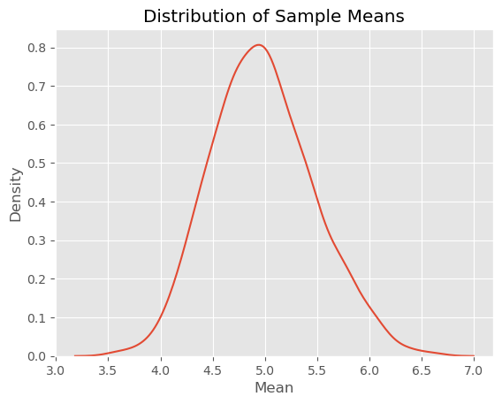

```python
np.random.seed(42)
lambda_e = 0.2
expected_exp_mean = 1 / lambda_e  # scale

means = []

for _ in range(1000):
    m = np.random.exponential(scale=expected_exp_mean, size=100).mean()
    means.append(m)

sns.kdeplot(means)
plt.xlabel("Mean")
plt.ylabel("Density")
plt.title("Distribution of Sample Means")
plt.show()
```

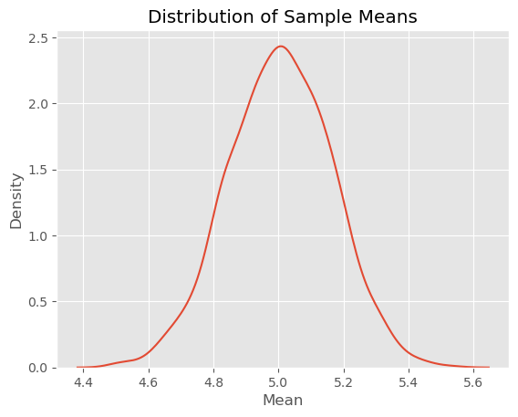

```python
np.random.seed(42)
lambda_e = 0.2
expected_exp_mean = 1 / lambda_e  # scale

means = []

for _ in range(1000):
    m = np.random.exponential(scale=expected_exp_mean, size=1000).mean()
    means.append(m)

sns.kdeplot(means)
plt.xlabel("Mean")
plt.ylabel("Density")
plt.title("Distribution of Sample Means")
plt.show()
```

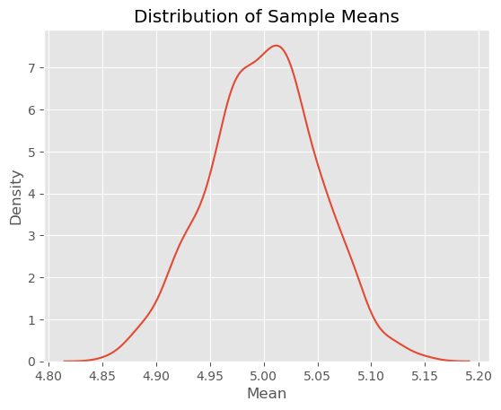

```python
np.random.seed(42)
lambda_e = 0.2
expected_exp_mean = 1 / lambda_e  # scale

means = []

for _ in range(1000):
    m = np.random.exponential(scale=expected_exp_mean, size=10000).mean()
    means.append(m)

sns.kdeplot(means)
plt.xlabel("Mean")
plt.ylabel("Density")
plt.title("Distribution of Sample Means")
plt.show()
```

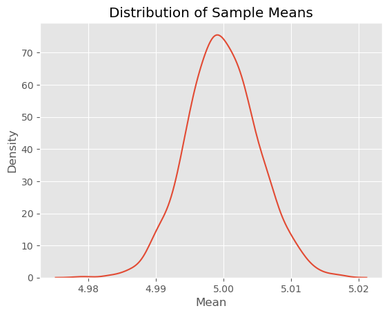

```python
np.random.seed(42)
lambda_e = 0.2
expected_exp_mean = 1 / lambda_e  # scale

means = []

for _ in range(1000):
    m = np.random.exponential(scale=expected_exp_mean, size=1000000).mean()
    means.append(m)

sns.kdeplot(means)
plt.xlabel("Mean")
plt.ylabel("Density")
plt.title("Distribution of Sample Means")
plt.show()
```

#### **Вывод:** аналогично можем заметить, что распределение становится все более похожим на нормальное.

### Задание 3. Сгенерируйте выборки маленького/среднего/большого размера и для каждой из них постройте:

- асимптотический доверительный интервал для среднего значения на базе ЦПТ,
- точный доверительный интервал для среднего значения (на базе t-критического значения),
- эфронов доверительный интервал для среднего, медианы, моды, дисперсии.

### Запутался с комментариями на лекции по заданию, оставил, как было, если идея реализована неправильно - переделаю

```python
small_size = 10
avg_size = 100
big_size = 10000

np.random.seed(42)
lambda_e = 0.2
size_new = 100000

# Математическое ожидание для распределения
expected_exp_mean = 1 / lambda_e  # scale

# Генерация распределения
exp_distribution = np.random.exponential(scale=expected_exp_mean, size=size_new)

small_sample = np.random.choice(exp_distribution, size=small_size, replace=True)
avg_sample = np.random.choice(exp_distribution, size=avg_size, replace=True)
big_sample = np.random.choice(exp_distribution, size=big_size, replace=True)
```

#### Задание 3.1. Асимптотический доверительный интервал для среднего значения на базе ЦП

**Асимптотический доверительный интервал:**

```python
def norm_conf_int(alpha, mean_hat, std_hat, margin=5):
    """
        Строит 95% асимптотически-нормальный доверительный интервал
    """

    plt.figure(figsize=(10,5))
    xs = np.linspace(mean_hat - margin, mean_hat + margin)
    pdf = sts.norm(mean_hat, std_hat).pdf(xs)

    plt.plot(xs, pdf)
    plt.ylabel('$f(x)$', fontsize=18)
    plt.xlabel('$x$', fontsize=18)

    left, right = sts.norm.interval(1 - alpha, loc=mean_hat, scale=std_hat)

    for i in [left, right]:
        y_max = plt.ylim()[1]
        plt.axvline(i, color="blue", linestyle='dashed', lw=2)

        if i == left:
            xq = np.linspace(mean_hat - margin, left)
        else:
            xq = np.linspace(right, mean_hat + margin)

        text_margin = 0.05
        plt.text(i + text_margin, 0.8*y_max, round(i, 2), color="blue", fontsize=14)
        yq = sts.norm(mean_hat, std_hat).pdf(xq)
        plt.fill_between(xq, 0, yq, color='blue', alpha=0.3)

    return left, right
```

```
Доверительный интервал для маленькой выборки:
(-4.391627333801465, 15.507618257417722)
Доверительный интервал для средней выборки:
(-6.323110540638299, 17.448400525969344)
Доверительный интервал для большой выборки:
(-4.581051460679816, 14.507420651590959)
```

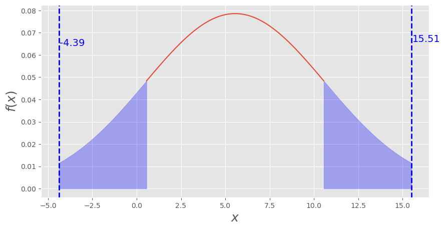

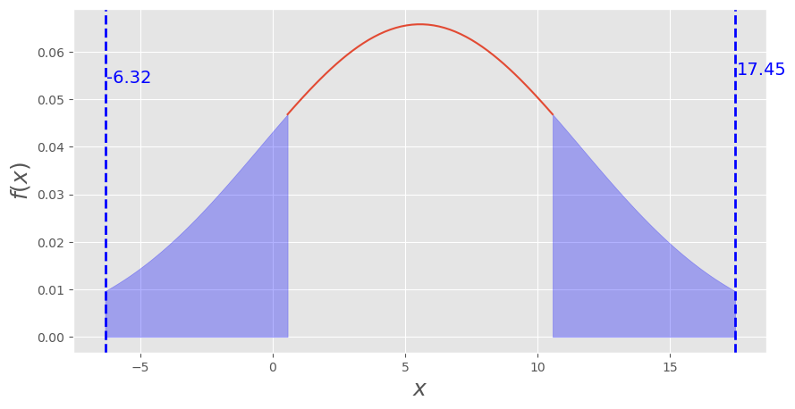

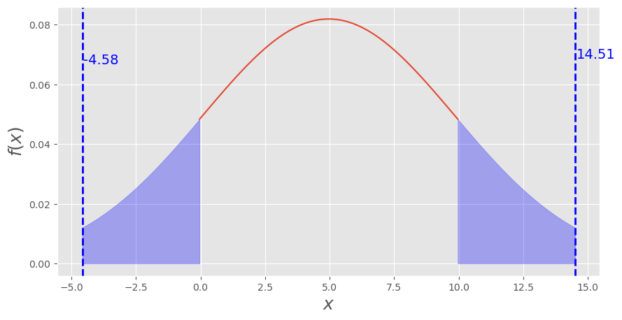

```python
# ДЛЯ МАЛЕНЬКОЙ
alpha = 0.05
small_size = 10
mu_hat = small_sample.mean()
sd_hat = small_sample.std()

norm_conf_int_small = norm_conf_int(alpha, mu_hat, sd_hat, margin=5)

# ДЛЯ СРЕДНЕЙ
alpha = 0.05
avg_size = 10
mu_hat = avg_sample.mean()
sd_hat = avg_sample.std()

norm_conf_int_avg = norm_conf_int(alpha, mu_hat, sd_hat, margin=5)

# ДЛЯ БОЛЬШОЙ
alpha = 0.05
big_size = 10
mu_hat = big_sample.mean()
sd_hat = big_sample.std()

norm_conf_int_big = norm_conf_int(alpha, mu_hat, sd_hat, margin=5)

print(f"Доверительный интервал для маленькой выборки:\n{norm_conf_int_small}\nДоверительный интервал для средней выборки:\n{norm_conf_int_avg}\nДоверительный интервал для большой выборки:\n{norm_conf_int_big}")
```

#### Задание 3.2. Точный доверительный интервал для среднего значения (на базе t-критического значения)

**Точный доверительный интервал:**

$$ \bar x \pm t_{1 - \frac{\alpha}{2}} \cdot \sqrt{\frac{\hat s^2}{n}}. $$

```python
# ДЛЯ МАЛЕНЬКОЙ

small_size = 10
t_rv = stats.t(small_size-1)

alpha = 0.05
t_crit = t_rv.ppf(1 - alpha/2)

mu_hat = small_sample.mean()
var_hat = np.var(small_sample, ddof=1) / small_size # уже нормированный на n

left = mu_hat - t_crit*np.sqrt(var_hat)
right = mu_hat + t_crit*np.sqrt(var_hat)

print("Доверительный интервал [{:.4}; {:.4}] ширины {:.4}".format(left, right, right - left))

# ДЛЯ СРЕДНЕЙ
avg_size = 100
t_rv = stats.t(avg_size-1)

alpha = 0.05
t_crit = t_rv.ppf(1 - alpha/2)

mu_hat = avg_sample.mean()
var_hat = np.var(avg_sample, ddof=1) / avg_size # уже нормированный на n

left = mu_hat - t_crit*np.sqrt(var_hat)
right = mu_hat + t_crit*np.sqrt(var_hat)

print("Доверительный интервал [{:.4}; {:.4}] ширины {:.4}".format(left, right, right - left))

# ДЛЯ БОЛЬШОЙ
big_size = 10000
t_rv = stats.t(big_size-1)

alpha = 0.05
t_crit = t_rv.ppf(1 - alpha/2)

mu_hat = big_sample.mean()
var_hat = np.var(big_sample, ddof=1) / big_size # уже нормированный на n

left = mu_hat - t_crit*np.sqrt(var_hat)
right = mu_hat + t_crit*np.sqrt(var_hat)

print("Доверительный интервал [{:.4}; {:.4}] ширины {:.4}".format(left, right, right - left))
```

```
Доверительный интервал [1.73; 9.386] ширины 7.656
Доверительный интервал [4.353; 6.772] ширины 2.419
Доверительный интервал [4.868; 5.059] ширины 0.1909
```

#### Задание 3.3. Эфронов доверительный интервал для среднего, медианы, моды, дисперсии.)

#### Для среднего

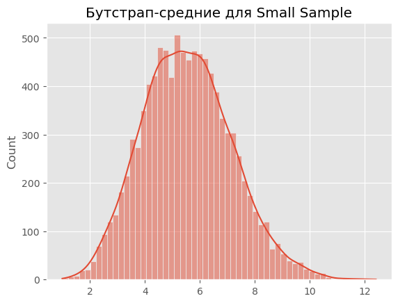

```
95% доверительный интервал для small sample: [2.61 8.92]
```

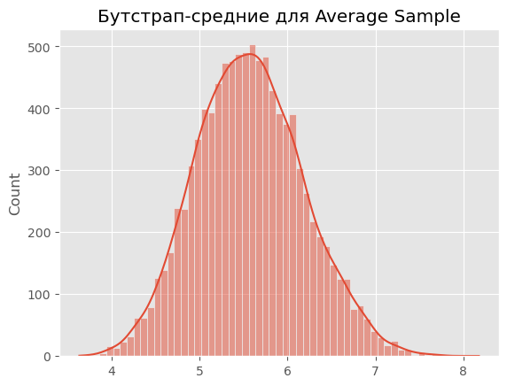

```
95% доверительный интервал для average sample: [4.43 6.82]
```

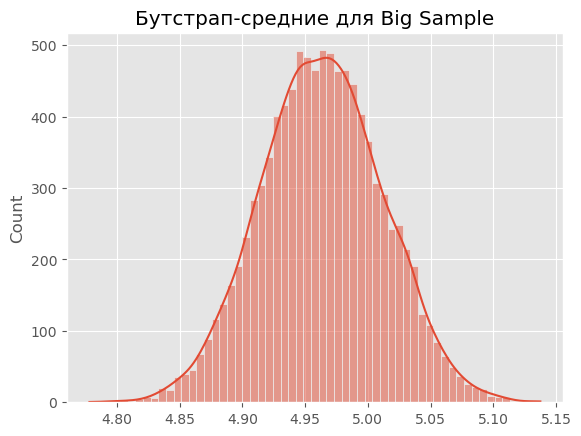

```
95% доверительный интервал для big sample: [4.87 5.06]
```

```python
np.random.seed(42)

# Запустим бутстрап

def bootstrap_mean(sample):
    means_list = []
    for _ in range(10000):
        bs_sample = np.random.choice(sample, size=len(sample), replace=True)
        means_list.append(bs_sample.mean())
    return means_list

# Бутстрап для small_sample
small_means = bootstrap_mean(small_sample)
sns.histplot(small_means, kde=True)
plt.title("Бутстрап-средние для Small Sample")
plt.show()

# Доверительный интервал для small_sample
small_ci = np.percentile(small_means, q=[2.5, 97.5]).round(2)
print(f"95% доверительный интервал для small sample: {small_ci}")

# Бутстрап для avg_sample
avg_means = bootstrap_mean(avg_sample)
sns.histplot(avg_means, kde=True)
plt.title("Бутстрап-средние для Average Sample")
plt.show()

# Доверительный интервал для avg_sample
avg_ci = np.percentile(avg_means, q=[2.5, 97.5]).round(2)
print(f"95% доверительный интервал для average sample: {avg_ci}")

# Бутстрап для big_sample
big_means = bootstrap_mean(big_sample)
sns.histplot(big_means, kde=True)
plt.title("Бутстрап-средние для Big Sample")
plt.show()

# Доверительный интервал для big_sample
big_ci = np.percentile(big_means, q=[2.5, 97.5]).round(2)
print(f"95% доверительный интервал для big sample: {big_ci}")
```

#### Для медианы

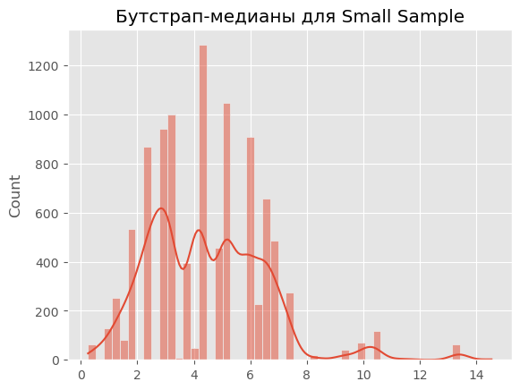

```
95% доверительный интервал для small sample: [1.36 9.94]
```

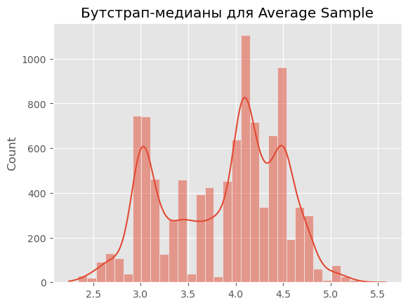

```
95% доверительный интервал для average sample: [2.71 4.78]
```

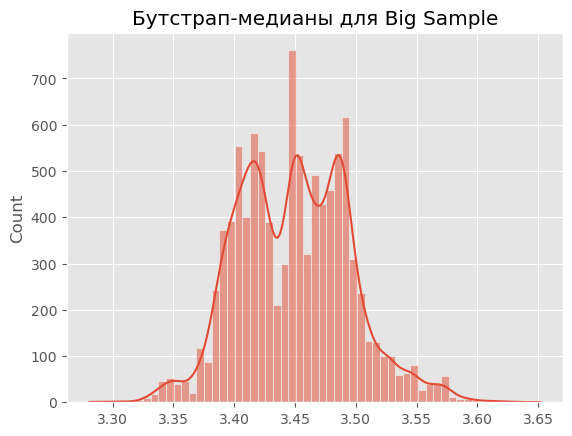

```
95% доверительный интервал для big sample: [3.37 3.55]
```

```python
np.random.seed(42)

# Запустим бутстрап

def bootstrap_median(sample):
    medians_list = []
    for _ in range(10000):
        bs_sample = np.random.choice(sample, size=len(sample), replace=True)
        medians_list.append(np.median(bs_sample))
    return medians_list

# Бутстрап для small_sample
small_medians = bootstrap_median(small_sample)
sns.histplot(small_medians, kde=True)
plt.title("Бутстрап-медианы для Small Sample")
plt.show()

# Доверительный интервал для small_sample
small_ci = np.percentile(small_medians, q=[2.5, 97.5]).round(2)
print(f"95% доверительный интервал для small sample: {small_ci}")

# Бутстрап для avg_sample
avg_medians = bootstrap_median(avg_sample)
sns.histplot(avg_medians, kde=True)
plt.title("Бутстрап-медианы для Average Sample")
plt.show()

# Доверительный интервал для avg_sample
avg_ci = np.percentile(avg_medians, q=[2.5, 97.5]).round(2)
print(f"95% доверительный интервал для average sample: {avg_ci}")

# Бутстрап для big_sample
big_medians = bootstrap_median(big_sample)
sns.histplot(big_medians, kde=True)
plt.title("Бутстрап-медианы для Big Sample")
plt.show()

# Доверительный интервал для big_sample
big_ci = np.percentile(big_medians, q=[2.5, 97.5]).round(2)
print(f"95% доверительный интервал для big sample: {big_ci}")
```

#### Для моды

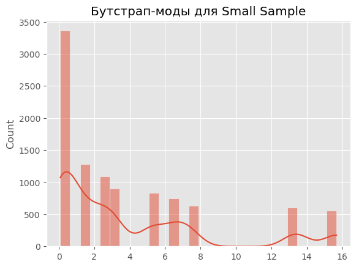

```
95% доверительный интервал для small sample: [ 0.08 15.68]
```

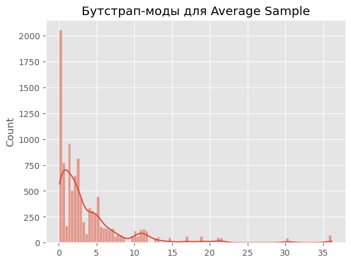

```
95% доверительный интервал для average sample: [ 0.09 19.05]
```

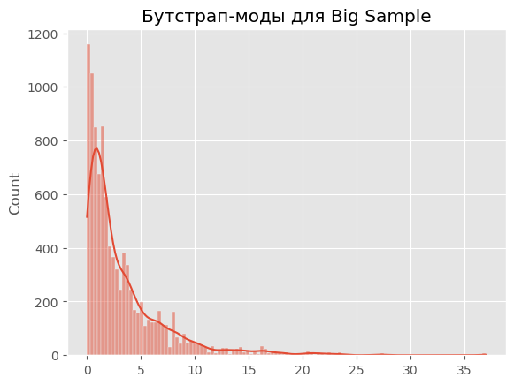

```
95% доверительный интервал для big sample: [ 0.05 15.05]
```

```python
np.random.seed(42)

def bootstrap_mode(sample):
    modes_list = []
    for _ in range(10000):
        bs_sample = np.random.choice(sample, size=len(sample), replace=True)
        mode = sts.mode(bs_sample, keepdims=False).mode
        modes_list.append(mode)
    return modes_list

# Бутстрап для small_sample
small_modes = bootstrap_mode(small_sample)
sns.histplot(small_modes, kde=True)
plt.title("Бутстрап-моды для Small Sample")
plt.show()

# Доверительный интервал для small_sample
small_ci = np.percentile(small_modes, q=[2.5, 97.5]).round(2)
print(f"95% доверительный интервал для small sample: {small_ci}")

# Бутстрап для avg_sample
avg_modes = bootstrap_mode(avg_sample)
sns.histplot(avg_modes, kde=True)
plt.title("Бутстрап-моды для Average Sample")
plt.show()

# Доверительный интервал для avg_sample
avg_ci = np.percentile(avg_modes, q=[2.5, 97.5]).round(2)
print(f"95% доверительный интервал для average sample: {avg_ci}")

# Бутстрап для big_sample
big_modes = bootstrap_mode(big_sample)
sns.histplot(big_modes, kde=True)
plt.title("Бутстрап-моды для Big Sample")
plt.show()

# Доверительный интервал для big_sample
big_ci = np.percentile(big_modes, q=[2.5, 97.5]).round(2)
print(f"95% доверительный интервал для big sample: {big_ci}")
```

#### Для дисперсии

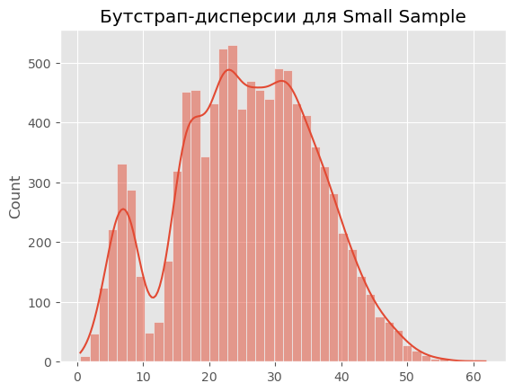

```
95% доверительный интервал для small sample: [ 5.15 45.35]
```

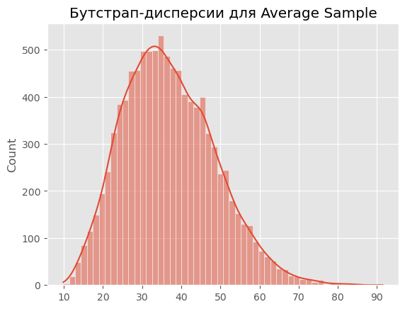

```
95% доверительный интервал для average sample: [17.26 61.8 ]
```

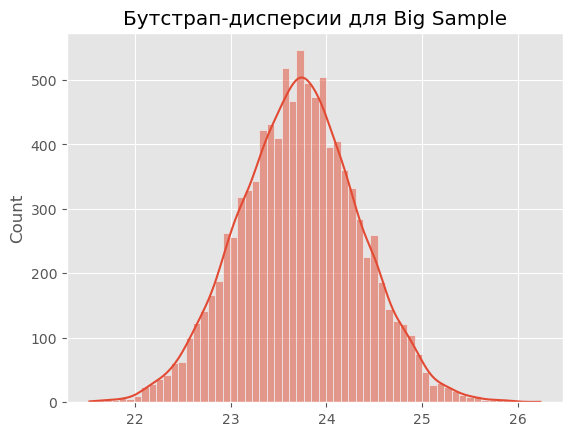

```
95% доверительный интервал для big sample: [22.49 24.93]
```

```python
np.random.seed(42)

def bootstrap_variance(sample):
    variances_list = []
    for _ in range(10000):
        bs_sample = np.random.choice(sample, size=len(sample), replace=True)
        variance = np.var(bs_sample, ddof=1)
        variances_list.append(variance)
    return variances_list

# Бутстрап для small_sample
small_variances = bootstrap_variance(small_sample)
sns.histplot(small_variances, kde=True)
plt.title("Бутстрап-дисперсии для Small Sample")
plt.show()

# Доверительный интервал для small_sample
small_ci = np.percentile(small_variances, q=[2.5, 97.5]).round(2)
print(f"95% доверительный интервал для small sample: {small_ci}")

# Бутстрап для avg_sample
avg_variances = bootstrap_variance(avg_sample)
sns.histplot(avg_variances, kde=True)
plt.title("Бутстрап-дисперсии для Average Sample")
plt.show()

# Доверительный интервал для avg_sample
avg_ci = np.percentile(avg_variances, q=[2.5, 97.5]).round(2)
print(f"95% доверительный интервал для average sample: {avg_ci}")

# Бутстрап для big_sample
big_variances = bootstrap_variance(big_sample)
sns.histplot(big_variances, kde=True)
plt.title("Бутстрап-дисперсии для Big Sample")
plt.show()

# Доверительный интервал для big_sample
big_ci = np.percentile(big_variances, q=[2.5, 97.5]).round(2)
print(f"95% доверительный интервал для big sample: {big_ci}")
```

[output not shown]